# ggplot introduction

# Visualizations using ggplot

**Dataset Diamonds:**

The diamonds data set - part of the ggplot library

**Variables:**

`carat` — This is the weight of a diamond

`cut` — This is the quality of the diamond cut; Fair, Good, Very Good, Premium, Ideal.

`color` — The color of a diamond from D (best) to J (worst).

`clarity` — a measurement of how clear the diamond is; I1 (worst), SI2, SI1, VS2, VS1, VVS2, VVS1, IF (best).

`price` — price of the diamond

`depth` — total depth percentage = z / mean(x, y) = 2 * z / (x + y) (43–79)

`x` — length of diamond in mm

`y` — width in mm

`z` — depth in mm

```r
head(diamonds)
```

```
## # A tibble: 6 × 10
##   carat cut       color clarity depth table price     x     y     z
##   <dbl> <ord>     <ord> <ord>   <dbl> <dbl> <int> <dbl> <dbl> <dbl>
## 1  0.23 Ideal     E     SI2      61.5    55   326  3.95  3.98  2.43
## 2  0.21 Premium   E     SI1      59.8    61   326  3.89  3.84  2.31
## 3  0.23 Good      E     VS1      56.9    65   327  4.05  4.07  2.31
## 4  0.29 Premium   I     VS2      62.4    58   334  4.2   4.23  2.63
## 5  0.31 Good      J     SI2      63.3    58   335  4.34  4.35  2.75
## 6  0.24 Very Good J     VVS2     62.8    57   336  3.94  3.96  2.48
```

## ggplot object

- ggplot visualizations consist of three main elements
  - **data** (dataset)
  - **aes** - aesthetic mapping (mapping variables to the axis)
  - **geom** (layer for visualization)

**Example:**

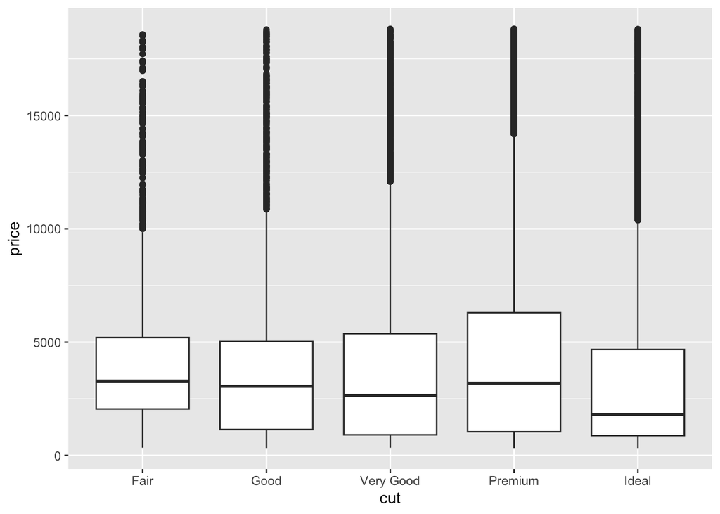

```r
ggplot(data = diamonds,
       mapping = aes(
         x = cut,
         y = price,
       )) + geom_boxplot()
```